# ANCOVA in Vocabulario (Vocabulario)

Geiser C. Challco geiser@alumni.usp.br

- Descriptive Statistics of Initial Data
- ANCOVA and Pairwise for one factor: **grupo**
  - Without remove non-normal data
  - Computing ANCOVA and PairWise After removing non-normal data (OK)
    - Plots for ancova
    - Checking linearity assumption
    - Checking normality and homogeneity
- ANCOVA and Pairwise for two factors **grupo:Sexo**
  - Without remove non-normal data
  - Computing ANCOVA and PairWise After removing non-normal data (OK)
    - Plots for ancova
    - Checking linearity assumption
    - Checking normality and homogeneity
- ANCOVA and Pairwise for two factors **grupo:Zona**
  - Without remove non-normal data
  - Computing ANCOVA and PairWise After removing non-normal data (OK)
    - Plots for ancova
    - Checking linearity assumption
    - Checking normality and homogeneity
- ANCOVA and Pairwise for two factors **grupo:Cor.Raca**
  - Without remove non-normal data
  - Computing ANCOVA and PairWise After removing non-normal data (OK)
    - Plots for ancova
    - Checking linearity assumption
    - Checking normality and homogeneity
- ANCOVA and Pairwise for two factors **grupo:Serie**
  - Without remove non-normal data
  - Computing ANCOVA and PairWise After removing non-normal data (OK)
    - Plots for ancova
    - Checking linearity assumption
    - Checking normality and homogeneity
- Summary of Results
  - Descriptive Statistics
  - ANCOVA Table Comparison
  - PairWise Table Comparison
  - EMMS Table Comparison

**NOTE**:

- Teste ANCOVA para determinar se houve diferenças significativas no Vocabulario (medido usando pre- e pos-testes).
- ANCOVA test to determine whether there were significant differences in Vocabulario (measured using pre- and post-tests).

# Descriptive Statistics of Initial Data

```r
df <- get.descriptives(dat, c(dv.pre, dv.pos), c("grupo"),
                       include.global = T, symmetry.test = T, normality.test = F)
df <- plyr::rbind.fill(
  df, do.call(plyr::rbind.fill, lapply(lfatores2, FUN = function(f) {
    if (nrow(dat) > 0 && sum(!is.na(unique(dat[[f]]))) > 1)
      get.descriptives(dat, c(dv.pre,dv.pos), c("grupo", f),
                       symmetry.test = T, normality.test = F)
    }))
)
(df <- df[,c(fatores1[fatores1 %in% colnames(df)],"variable",
             colnames(df)[!colnames(df) %in% c(fatores1,"variable")])])
```

```
##           grupo Sexo   Zona Cor.Raca Serie  variable   n   mean median min max    sd    se     ci   iqr symmetry
## 1      Controle <NA>   <NA>     <NA>  <NA> vocab.pre 102 12.461   13.0   4  16 2.977 0.295  0.585  4.00       NO
## 2  Experimental <NA>   <NA>     <NA>  <NA> vocab.pre 106 12.868   13.5   1  16 2.957 0.287  0.569  4.00       NO
## 3          <NA> <NA>   <NA>     <NA>  <NA> vocab.pre 208 12.668   13.0   1  16 2.967 0.206  0.406  4.00       NO
## 4      Controle <NA>   <NA>     <NA>  <NA> vocab.pos 102 15.108   15.0   2  29 5.308 0.526  1.043  6.75      YES
## 5  Experimental <NA>   <NA>     <NA>  <NA> vocab.pos 106 17.821   18.0   2  42 7.087 0.688  1.365  9.00       NO
## 6          <NA> <NA>   <NA>     <NA>  <NA> vocab.pos 208 16.490   16.0   2  42 6.409 0.444  0.876  8.00       NO
## 7      Controle    F   <NA>     <NA>  <NA> vocab.pre  39 12.692   14.0   6  16 2.993 0.479  0.970  4.00       NO
## 8      Controle    M   <NA>     <NA>  <NA> vocab.pre  63 12.317   13.0   4  16 2.983 0.376  0.751  4.00       NO
## 9  Experimental    F   <NA>     <NA>  <NA> vocab.pre  52 12.692   13.0   1  16 3.153 0.437  0.878  4.25       NO
## 10 Experimental    M   <NA>     <NA>  <NA> vocab.pre  54 13.037   14.0   5  16 2.774 0.378  0.757  4.00       NO
## 11     Controle    F   <NA>     <NA>  <NA> vocab.pos  39 15.974   16.0   4  29 5.348 0.856  1.734  6.00      YES
## 12     Controle    M   <NA>     <NA>  <NA> vocab.pos  63 14.571   15.0   2  25 5.254 0.662  1.323  7.50      YES
## 13 Experimental    F   <NA>     <NA>  <NA> vocab.pos  52 18.269   18.5   2  33 6.604 0.916  1.839  9.50      YES
## 14 Experimental    M   <NA>     <NA>  <NA> vocab.pos  54 17.389   16.0   5  42 7.560 1.029  2.063  9.00       NO
```

[output cut: 98 more lines]

| grupo | Sexo | Zona | Cor.Raca | Serie | variable | n | mean | median | min | max | sd | se | ci | iqr | symmetry | skewness | kurtosis |
| --- | --- | --- | --- | --- | --- | --- | --- | --- | --- | --- | --- | --- | --- | --- | --- | --- | --- |
| Controle |  |  |  |  | vocab.pre | 102 | 12.461 | 13.0 | 4 | 16 | 2.977 | 0.295 | 0.585 | 4.00 | NO | -0.811 | -0.173 |
| Experimental |  |  |  |  | vocab.pre | 106 | 12.868 | 13.5 | 1 | 16 | 2.957 | 0.287 | 0.569 | 4.00 | NO | -1.129 | 1.469 |
|  |  |  |  |  | vocab.pre | 208 | 12.668 | 13.0 | 1 | 16 | 2.967 | 0.206 | 0.406 | 4.00 | NO | -0.973 | 0.641 |
| Controle |  |  |  |  | vocab.pos | 102 | 15.108 | 15.0 | 2 | 29 | 5.308 | 0.526 | 1.043 | 6.75 | YES | -0.034 | -0.132 |
| Experimental |  |  |  |  | vocab.pos | 106 | 17.821 | 18.0 | 2 | 42 | 7.087 | 0.688 | 1.365 | 9.00 | NO | 0.593 | 0.553 |
|  |  |  |  |  | vocab.pos | 208 | 16.490 | 16.0 | 2 | 42 | 6.409 | 0.444 | 0.876 | 8.00 | NO | 0.568 | 0.971 |
| Controle | F |  |  |  | vocab.pre | 39 | 12.692 | 14.0 | 6 | 16 | 2.993 | 0.479 | 0.970 | 4.00 | NO | -0.669 | -0.829 |
| Controle | M |  |  |  | vocab.pre | 63 | 12.317 | 13.0 | 4 | 16 | 2.983 | 0.376 | 0.751 | 4.00 | NO | -0.888 | 0.106 |
| Experimental | F |  |  |  | vocab.pre | 52 | 12.692 | 13.0 | 1 | 16 | 3.153 | 0.437 | 0.878 | 4.25 | NO | -1.238 | 1.929 |
| Experimental | M |  |  |  | vocab.pre | 54 | 13.037 | 14.0 | 5 | 16 | 2.774 | 0.378 | 0.757 | 4.00 | NO | -0.881 | 0.122 |
| Controle | F |  |  |  | vocab.pos | 39 | 15.974 | 16.0 | 4 | 29 | 5.348 | 0.856 | 1.734 | 6.00 | YES | 0.126 | 0.020 |
| Controle | M |  |  |  | vocab.pos | 63 | 14.571 | 15.0 | 2 | 25 | 5.254 | 0.662 | 1.323 | 7.50 | YES | -0.149 | -0.449 |
| Experimental | F |  |  |  | vocab.pos | 52 | 18.269 | 18.5 | 2 | 33 | 6.604 | 0.916 | 1.839 | 9.50 | YES | 0.091 | -0.341 |
| Experimental | M |  |  |  | vocab.pos | 54 | 17.389 | 16.0 | 5 | 42 | 7.560 | 1.029 | 2.063 | 9.00 | NO | 0.941 | 1.062 |
| Controle |  | Rural |  |  | vocab.pre | 51 | 12.706 | 14.0 | 4 | 16 | 2.962 | 0.415 | 0.833 | 4.00 | NO | -0.936 | -0.036 |
| Controle |  | Urbana |  |  | vocab.pre | 19 | 12.368 | 12.0 | 6 | 16 | 2.650 | 0.608 | 1.277 | 3.50 | YES | -0.480 | -0.478 |
| Controle |  |  |  |  | vocab.pre | 32 | 12.125 | 12.0 | 5 | 16 | 3.230 | 0.571 | 1.165 | 4.00 | NO | -0.682 | -0.575 |
| Experimental |  | Rural |  |  | vocab.pre | 51 | 12.431 | 13.0 | 5 | 16 | 2.900 | 0.406 | 0.816 | 4.00 | NO | -0.631 | -0.324 |
| Experimental |  | Urbana |  |  | vocab.pre | 27 | 13.444 | 15.0 | 1 | 16 | 3.166 | 0.609 | 1.253 | 3.00 | NO | -2.277 | 6.164 |
| Experimental |  |  |  |  | vocab.pre | 28 | 13.107 | 14.0 | 6 | 16 | 2.833 | 0.535 | 1.098 | 5.25 | NO | -0.651 | -0.700 |
| Controle |  | Rural |  |  | vocab.pos | 51 | 14.686 | 15.0 | 2 | 26 | 5.652 | 0.791 | 1.590 | 8.00 | YES | -0.192 | -0.512 |
| Controle |  | Urbana |  |  | vocab.pos | 19 | 14.895 | 14.0 | 7 | 23 | 4.370 | 1.003 | 2.106 | 5.50 | YES | 0.075 | -0.952 |
| Controle |  |  |  |  | vocab.pos | 32 | 15.906 | 16.5 | 5 | 29 | 5.312 | 0.939 | 1.915 | 5.50 | YES | 0.263 | 0.002 |
| Experimental |  | Rural |  |  | vocab.pos | 51 | 17.843 | 18.0 | 2 | 42 | 8.088 | 1.133 | 2.275 | 11.00 | NO | 0.616 | 0.435 |
| Experimental |  | Urbana |  |  | vocab.pos | 27 | 17.741 | 16.0 | 9 | 28 | 5.606 | 1.079 | 2.218 | 8.50 | YES | 0.152 | -1.153 |
| Experimental |  |  |  |  | vocab.pos | 28 | 17.857 | 17.0 | 7 | 33 | 6.626 | 1.252 | 2.569 | 7.50 | NO | 0.600 | -0.239 |
| Controle |  |  | Branca |  | vocab.pre | 6 | 11.333 | 11.5 | 8 | 15 | 2.582 | 1.054 | 2.710 | 3.25 | YES | 0.043 | -1.718 |
| Controle |  |  | Indígena |  | vocab.pre | 2 | 15.000 | 15.0 | 15 | 15 | 0.000 | 0.000 | 0.000 | 0.00 | few data | 0.000 | 0.000 |
| Controle |  |  | Parda |  | vocab.pre | 36 | 12.861 | 13.0 | 7 | 16 | 2.576 | 0.429 | 0.872 | 3.00 | NO | -0.708 | -0.405 |
| Controle |  |  |  |  | vocab.pre | 58 | 12.241 | 13.0 | 4 | 16 | 3.246 | 0.426 | 0.854 | 4.00 | NO | -0.781 | -0.388 |
| Experimental |  |  | Branca |  | vocab.pre | 5 | 14.400 | 15.0 | 12 | 16 | 1.817 | 0.812 | 2.256 | 3.00 | YES | -0.272 | -2.077 |
| Experimental |  |  | Indígena |  | vocab.pre | 7 | 14.286 | 14.0 | 12 | 16 | 1.496 | 0.565 | 1.384 | 2.00 | YES | -0.157 | -1.643 |
| Experimental |  |  | Parda |  | vocab.pre | 41 | 12.488 | 13.0 | 1 | 16 | 3.370 | 0.526 | 1.064 | 4.00 | NO | -1.186 | 1.446 |
| Experimental |  |  | Preta |  | vocab.pre | 1 | 10.000 | 10.0 | 10 | 10 |  |  |  | 0.00 | few data | 0.000 | 0.000 |
| Experimental |  |  |  |  | vocab.pre | 52 | 12.885 | 13.0 | 5 | 16 | 2.791 | 0.387 | 0.777 | 4.00 | NO | -0.754 | -0.134 |
| Controle |  |  | Branca |  | vocab.pos | 6 | 14.833 | 14.0 | 10 | 20 | 4.708 | 1.922 | 4.941 | 8.25 | YES | 0.097 | -2.178 |
| Controle |  |  | Indígena |  | vocab.pos | 2 | 19.500 | 19.5 | 18 | 21 | 2.121 | 1.500 | 19.059 | 1.50 | few data | 0.000 | 0.000 |
| Controle |  |  | Parda |  | vocab.pos | 36 | 14.167 | 15.0 | 3 | 24 | 5.096 | 0.849 | 1.724 | 5.25 | YES | -0.333 | -0.384 |
| Controle |  |  |  |  | vocab.pos | 58 | 15.569 | 16.0 | 2 | 29 | 5.522 | 0.725 | 1.452 | 6.75 | YES | 0.108 | -0.219 |
| Experimental |  |  | Branca |  | vocab.pos | 5 | 15.600 | 16.0 | 9 | 23 | 6.107 | 2.731 | 7.583 | 10.00 | YES | 0.024 | -2.101 |
| Experimental |  |  | Indígena |  | vocab.pos | 7 | 17.143 | 18.0 | 13 | 21 | 3.132 | 1.184 | 2.897 | 4.00 | YES | -0.280 | -1.696 |
| Experimental |  |  | Parda |  | vocab.pos | 41 | 19.366 | 19.0 | 7 | 42 | 8.018 | 1.252 | 2.531 | 11.00 | NO | 0.661 | 0.134 |
| Experimental |  |  | Preta |  | vocab.pos | 1 | 13.000 | 13.0 | 13 | 13 |  |  |  | 0.00 | few data | 0.000 | 0.000 |
| Experimental |  |  |  |  | vocab.pos | 52 | 17.000 | 16.0 | 2 | 33 | 6.730 | 0.933 | 1.874 | 10.00 | YES | 0.213 | -0.330 |
| Controle |  |  |  | 6 ano | vocab.pre | 50 | 12.140 | 12.5 | 4 | 16 | 2.942 | 0.416 | 0.836 | 3.75 | NO | -0.615 | -0.231 |
| Controle |  |  |  | 7 ano | vocab.pre | 32 | 12.500 | 13.5 | 5 | 16 | 3.059 | 0.541 | 1.103 | 4.00 | NO | -0.894 | -0.314 |
| Controle |  |  |  | 8 ano | vocab.pre | 13 | 12.308 | 13.0 | 6 | 16 | 3.276 | 0.909 | 1.980 | 4.00 | NO | -0.633 | -1.001 |
| Controle |  |  |  | 9 ano | vocab.pre | 7 | 14.857 | 15.0 | 13 | 16 | 1.069 | 0.404 | 0.989 | 1.00 | YES | -0.472 | -1.267 |
| Experimental |  |  |  | 6 ano | vocab.pre | 48 | 12.667 | 13.0 | 6 | 16 | 2.747 | 0.396 | 0.798 | 5.25 | YES | -0.418 | -0.620 |
| Experimental |  |  |  | 7 ano | vocab.pre | 30 | 13.533 | 14.0 | 1 | 16 | 3.401 | 0.621 | 1.270 | 3.00 | NO | -2.219 | 4.794 |
| Experimental |  |  |  | 8 ano | vocab.pre | 19 | 11.842 | 12.0 | 6 | 16 | 2.949 | 0.677 | 1.421 | 5.00 | YES | -0.162 | -1.229 |
| Experimental |  |  |  | 9 ano | vocab.pre | 9 | 13.889 | 15.0 | 11 | 16 | 1.833 | 0.611 | 1.409 | 2.00 | NO | -0.614 | -1.368 |
| Controle |  |  |  | 6 ano | vocab.pos | 50 | 14.200 | 15.0 | 2 | 26 | 4.949 | 0.700 | 1.406 | 6.00 | YES | -0.279 | -0.112 |
| Controle |  |  |  | 7 ano | vocab.pos | 32 | 16.594 | 16.5 | 7 | 26 | 4.983 | 0.881 | 1.797 | 7.00 | YES | -0.002 | -0.897 |
| Controle |  |  |  | 8 ano | vocab.pos | 13 | 13.077 | 14.0 | 3 | 25 | 6.034 | 1.674 | 3.646 | 6.00 | YES | 0.272 | -0.781 |
| Controle |  |  |  | 9 ano | vocab.pos | 7 | 18.571 | 19.0 | 12 | 29 | 5.623 | 2.125 | 5.200 | 5.00 | NO | 0.546 | -0.904 |
| Experimental |  |  |  | 6 ano | vocab.pos | 48 | 17.958 | 16.5 | 2 | 42 | 7.423 | 1.071 | 2.155 | 9.25 | NO | 0.807 | 1.011 |
| Experimental |  |  |  | 7 ano | vocab.pos | 30 | 16.900 | 18.0 | 5 | 29 | 6.326 | 1.155 | 2.362 | 10.00 | YES | 0.013 | -1.022 |
| Experimental |  |  |  | 8 ano | vocab.pos | 19 | 16.947 | 16.0 | 7 | 33 | 6.696 | 1.536 | 3.227 | 8.00 | NO | 0.508 | -0.335 |
| Experimental |  |  |  | 9 ano | vocab.pos | 9 | 22.000 | 21.0 | 8 | 37 | 8.047 | 2.682 | 6.185 | 6.00 | YES | 0.145 | -0.564 |

# ANCOVA and Pairwise for one factor: **grupo**

## Without remove non-normal data

```r
pdat = remove_group_data(dat[!is.na(dat[["grupo"]]),], "vocab.pos", "grupo")

pdat.long <- rbind(pdat[,c("id","grupo")], pdat[,c("id","grupo")])
pdat.long[["time"]] <- c(rep("pre", nrow(pdat)), rep("pos", nrow(pdat)))
pdat.long[["time"]] <- factor(pdat.long[["time"]], c("pre","pos"))
pdat.long[["vocab"]] <- c(pdat[["vocab.pre"]], pdat[["vocab.pos"]])

aov = anova_test(pdat, vocab.pos ~ vocab.pre + grupo)
laov[["grupo"]] <- get_anova_table(aov)
```

```r
pwc <- emmeans_test(pdat, vocab.pos ~ grupo, covariate = vocab.pre,
                    p.adjust.method = "bonferroni")
```

```r
pwc.long <- emmeans_test(dplyr::group_by_at(pdat.long, "grupo"),
                          vocab ~ time,
                          p.adjust.method = "bonferroni")
lpwc[["grupo"]] <- plyr::rbind.fill(pwc, pwc.long)
```

```r
ds <- get.descriptives(pdat, "vocab.pos", "grupo", covar = "vocab.pre")
ds <- merge(ds[ds$variable != "vocab.pre",],
            ds[ds$variable == "vocab.pre", !colnames(ds) %in% c("variable")],
            by = "grupo", all.x = T, suffixes = c("", ".vocab.pre"))
ds <- merge(get_emmeans(pwc), ds, by = "grupo", suffixes = c(".emms", ""))
ds <- ds[,c("grupo","n","mean.vocab.pre","se.vocab.pre","mean","se","emmean","se.emms")]

colnames(ds) <- c("grupo", "N", paste0(c("M","SE")," (pre)"),
                  paste0(c("M","SE"), " (unadj)"), paste0(c("M", "SE"), " (adj)"))

lemms[["grupo"]] <- ds
```

## Computing ANCOVA and PairWise After removing non-normal data (OK)

```r
wdat = pdat

res = residuals(lm(vocab.pos ~ vocab.pre + grupo, data = wdat))
non.normal = getNonNormal(res, wdat$id, plimit = 0.05)

wdat = wdat[!wdat$id %in% non.normal,]

wdat.long <- rbind(wdat[,c("id","grupo")], wdat[,c("id","grupo")])
wdat.long[["time"]] <- c(rep("pre", nrow(wdat)), rep("pos", nrow(wdat)))
wdat.long[["time"]] <- factor(wdat.long[["time"]], c("pre","pos"))
wdat.long[["vocab"]] <- c(wdat[["vocab.pre"]], wdat[["vocab.pos"]])

ldat[["grupo"]] = wdat

(non.normal)
```

```
## [1] "P852"
```

```r
aov = anova_test(wdat, vocab.pos ~ vocab.pre + grupo)
laov[["grupo"]] <- merge(get_anova_table(aov), laov[["grupo"]], by="Effect", suffixes = c("","'"))

(df = get_anova_table(aov))
```

```
## ANOVA Table (type II tests)
##
##      Effect DFn DFd      F        p p<.05   ges
## 1 vocab.pre   1 204 16.479 7.01e-05     * 0.075
## 2     grupo   1 204  7.679 6.00e-03     * 0.036
```

| Effect | DFn | DFd | F | p | p<.05 | ges |
| --- | --- | --- | --- | --- | --- | --- |
| vocab.pre | 1 | 204 | 16.479 | 0.000 | * | 0.075 |
| grupo | 1 | 204 | 7.679 | 0.006 | * | 0.036 |

| term | .y. | group1 | group2 | df | statistic | p | p.adj | p.adj.signif |
| --- | --- | --- | --- | --- | --- | --- | --- | --- |
| vocab.pre*grupo | vocab.pos | Controle | Experimental | 204 | -2.771 | 0.006 | 0.006 | ** |

```r
pwc.long <- emmeans_test(dplyr::group_by_at(wdat.long, "grupo"),
                         vocab ~ time,
                         p.adjust.method = "bonferroni")
lpwc[["grupo"]] <- merge(plyr::rbind.fill(pwc, pwc.long), lpwc[["grupo"]], by=c("grupo","term",".y.","group1","group2"), suffixes = c("","'"))
```

| grupo | term | .y. | group1 | group2 | df | statistic | p | p.adj | p.adj.signif |
| --- | --- | --- | --- | --- | --- | --- | --- | --- | --- |
| Controle | time | vocab | pre | pos | 410 | -3.96 | 0 | 0 | **** |
| Experimental | time | vocab | pre | pos | 410 | -7.17 | 0 | 0 | **** |

```r
ds <- get.descriptives(wdat, "vocab.pos", "grupo", covar = "vocab.pre")
ds <- merge(ds[ds$variable != "vocab.pre",],
            ds[ds$variable == "vocab.pre", !colnames(ds) %in% c("variable")],
            by = "grupo", all.x = T, suffixes = c("", ".vocab.pre"))
ds <- merge(get_emmeans(pwc), ds, by = "grupo", suffixes = c(".emms", ""))
ds <- ds[,c("grupo","n","mean.vocab.pre","se.vocab.pre","mean","se","emmean","se.emms")]

colnames(ds) <- c("grupo", "N", paste0(c("M","SE")," (pre)"),
                  paste0(c("M","SE"), " (unadj)"), paste0(c("M", "SE"), " (adj)"))

lemms[["grupo"]] <- merge(ds, lemms[["grupo"]], by=c("grupo"), suffixes = c("","'"))
```

| grupo | N | M (pre) | SE (pre) | M (unadj) | SE (unadj) | M (adj) | SE (adj) |
| --- | --- | --- | --- | --- | --- | --- | --- |
| Controle | 102 | 12.461 | 0.295 | 15.108 | 0.526 | 15.223 | 0.579 |
| Experimental | 105 | 12.867 | 0.290 | 17.590 | 0.655 | 17.479 | 0.571 |

### Plots for ancova

```r
plots <- oneWayAncovaPlots(
  wdat, "vocab.pos", "grupo", aov, list("grupo"=pwc), addParam = c("mean_se"),
  font.label.size=10, step.increase=0.05, p.label="p.adj",
  subtitle = which(aov$Effect == "grupo"))
```

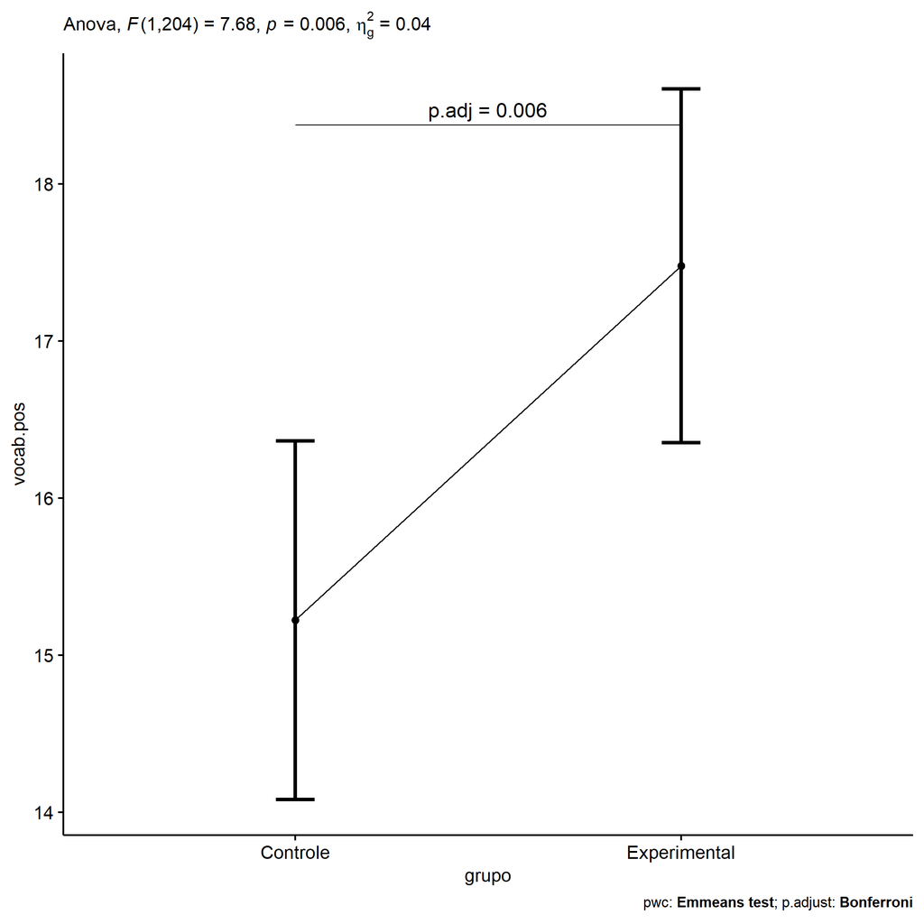

```r
if (!is.null(nrow(plots[["grupo"]]$data)))
  plots[["grupo"]] + ggplot2::scale_color_manual(values = color[["grupo"]])
```

```r
plots <- oneWayAncovaBoxPlots(
  wdat, "vocab.pos", "grupo", aov, pwc, covar = "vocab.pre",
  theme = "classic", color = color[["grupo"]],
  subtitle = which(aov$Effect == "grupo"))
```

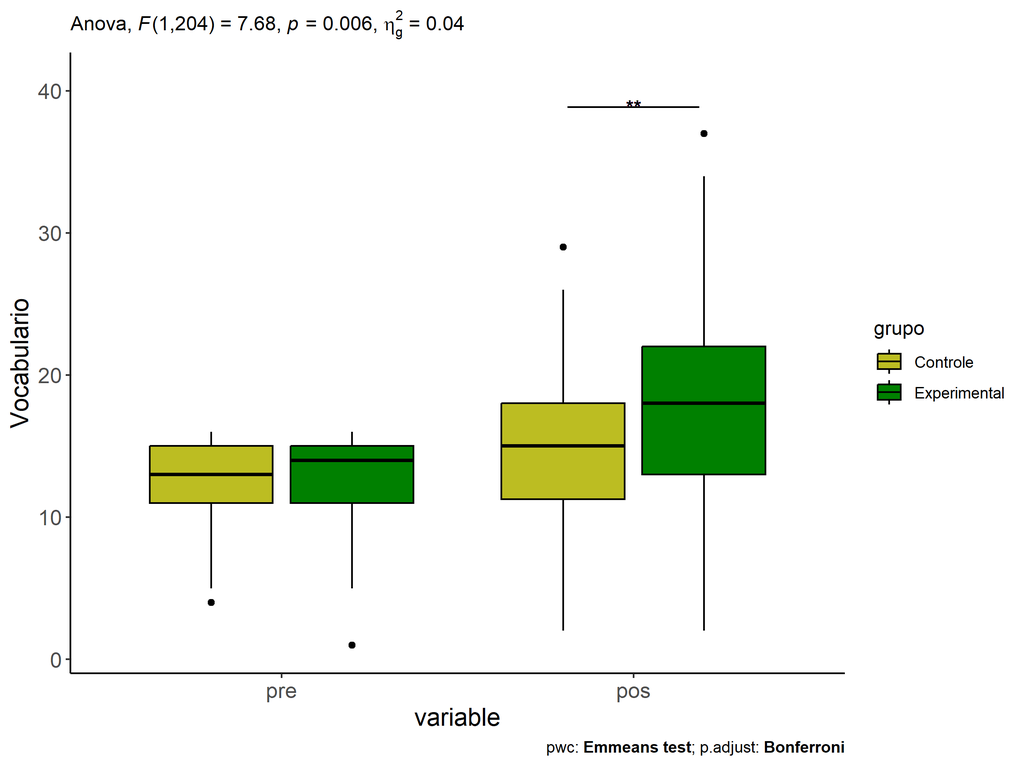

```r
if (length(unique(wdat[["grupo"]])) > 1)
  plots[["grupo"]] + ggplot2::ylab("Vocabulario") + ggplot2::scale_x_discrete(labels=c('pre', 'pos'))
```

```r
if (length(unique(wdat.long[["grupo"]])) > 1)
  plots <- oneWayAncovaBoxPlots(
    wdat.long, "vocab", "grupo", aov, pwc.long, pre.post = "time",
    theme = "classic", color = color$prepost)
```

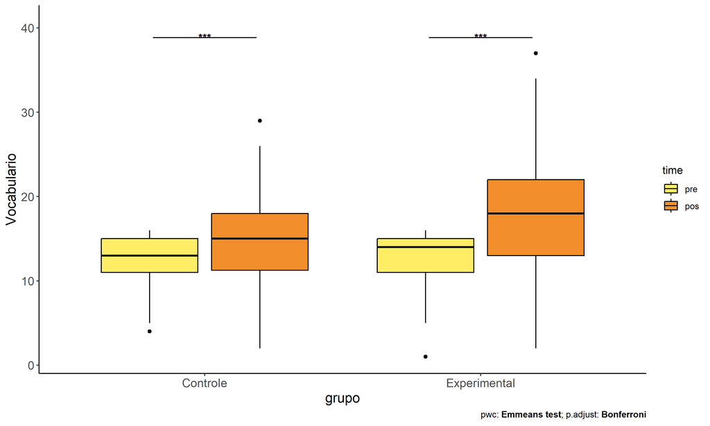

```r
if (length(unique(wdat.long[["grupo"]])) > 1)
  plots[["grupo"]] + ggplot2::ylab("Vocabulario")
```

### Checking linearity assumption

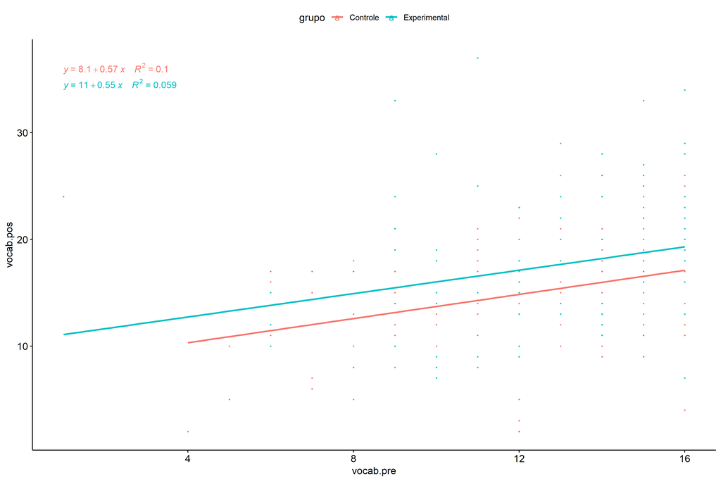

```r
ggscatter(wdat, x = "vocab.pre", y = "vocab.pos", size = 0.5,
          color = "grupo", add = "reg.line")+
  stat_regline_equation(
    aes(label =  paste(..eq.label.., ..rr.label.., sep = "~~~~"), color = grupo)
  )
```

### Checking normality and homogeneity

```r
res <- augment(lm(vocab.pos ~ vocab.pre + grupo, data = wdat))
```

```r
shapiro_test(res$.resid)
```

```
## # A tibble: 1 × 3
##   variable   statistic p.value
##   <chr>          <dbl>   <dbl>
## 1 res$.resid     0.990   0.139
```

```r
levene_test(res, .resid ~ grupo)
```

```
## # A tibble: 1 × 4
##     df1   df2 statistic      p
##   <int> <int>     <dbl>  <dbl>
## 1     1   205      5.68 0.0181
```

# ANCOVA and Pairwise for two factors **grupo:Sexo**

## Without remove non-normal data

```r
pdat = remove_group_data(dat[!is.na(dat[["grupo"]]) & !is.na(dat[["Sexo"]]),], "vocab.pos", c("grupo","Sexo"))

pdat.long <- rbind(pdat[,c("id","grupo","Sexo")], pdat[,c("id","grupo","Sexo")])
pdat.long[["time"]] <- c(rep("pre", nrow(pdat)), rep("pos", nrow(pdat)))
pdat.long[["time"]] <- factor(pdat.long[["time"]], c("pre","pos"))
pdat.long[["vocab"]] <- c(pdat[["vocab.pre"]], pdat[["vocab.pos"]])

aov = anova_test(pdat, vocab.pos ~ vocab.pre + grupo*Sexo)
laov[["grupo:Sexo"]] <- get_anova_table(aov)
```

```r
pwcs <- list()
pwcs[["Sexo"]] <- emmeans_test(
  group_by(pdat, grupo), vocab.pos ~ Sexo,
  covariate = vocab.pre, p.adjust.method = "bonferroni")
pwcs[["grupo"]] <- emmeans_test(
  group_by(pdat, Sexo), vocab.pos ~ grupo,
  covariate = vocab.pre, p.adjust.method = "bonferroni")

pwc <- plyr::rbind.fill(pwcs[["grupo"]], pwcs[["Sexo"]])
pwc <- pwc[,c("grupo","Sexo", colnames(pwc)[!colnames(pwc) %in% c("grupo","Sexo")])]
```

```r
pwc.long <- emmeans_test(dplyr::group_by_at(pdat.long, c("grupo","Sexo")),
                         vocab ~ time,
                         p.adjust.method = "bonferroni")
lpwc[["grupo:Sexo"]] <- plyr::rbind.fill(pwc, pwc.long)
```

```r
ds <- get.descriptives(pdat, "vocab.pos", c("grupo","Sexo"), covar = "vocab.pre")
ds <- merge(ds[ds$variable != "vocab.pre",],
            ds[ds$variable == "vocab.pre", !colnames(ds) %in% c("variable")],
            by = c("grupo","Sexo"), all.x = T, suffixes = c("", ".vocab.pre"))
ds <- merge(get_emmeans(pwcs[["grupo"]]), ds, by = c("grupo","Sexo"), suffixes = c(".emms", ""))
ds <- ds[,c("grupo","Sexo","n","mean.vocab.pre","se.vocab.pre","mean","se","emmean","se.emms")]

colnames(ds) <- c("grupo","Sexo", "N", paste0(c("M","SE")," (pre)"),
                  paste0(c("M","SE"), " (unadj)"), paste0(c("M", "SE"), " (adj)"))

lemms[["grupo:Sexo"]] <- ds
```

## Computing ANCOVA and PairWise After removing non-normal data (OK)

```r
wdat = pdat

res = residuals(lm(vocab.pos ~ vocab.pre + grupo*Sexo, data = wdat))
non.normal = getNonNormal(res, wdat$id, plimit = 0.05)

wdat = wdat[!wdat$id %in% non.normal,]

wdat.long <- rbind(wdat[,c("id","grupo","Sexo")], wdat[,c("id","grupo","Sexo")])
wdat.long[["time"]] <- c(rep("pre", nrow(wdat)), rep("pos", nrow(wdat)))
wdat.long[["time"]] <- factor(wdat.long[["time"]], c("pre","pos"))
wdat.long[["vocab"]] <- c(wdat[["vocab.pre"]], wdat[["vocab.pos"]])


ldat[["grupo:Sexo"]] = wdat

(non.normal)
```

```
## [1] "P852"
```

```r
aov = anova_test(wdat, vocab.pos ~ vocab.pre + grupo*Sexo)
laov[["grupo:Sexo"]] <- merge(get_anova_table(aov), laov[["grupo:Sexo"]], by="Effect", suffixes = c("","'"))

(df = get_anova_table(aov))
```

```
## ANOVA Table (type II tests)
##
##       Effect DFn DFd      F        p p<.05      ges
## 1  vocab.pre   1 202 16.590 6.66e-05     * 0.076000
## 2      grupo   1 202  6.601 1.10e-02     * 0.032000
## 3       Sexo   1 202  2.790 9.60e-02       0.014000
## 4 grupo:Sexo   1 202  0.044 8.35e-01       0.000216
```

| Effect | DFn | DFd | F | p | p<.05 | ges |
| --- | --- | --- | --- | --- | --- | --- |
| vocab.pre | 1 | 202 | 16.590 | 0.000 | * | 0.076 |
| grupo | 1 | 202 | 6.601 | 0.011 | * | 0.032 |
| Sexo | 1 | 202 | 2.790 | 0.096 |  | 0.014 |
| grupo:Sexo | 1 | 202 | 0.044 | 0.835 |  | 0.000 |

```r
pwcs <- list()
pwcs[["Sexo"]] <- emmeans_test(
  group_by(wdat, grupo), vocab.pos ~ Sexo,
  covariate = vocab.pre, p.adjust.method = "bonferroni")
pwcs[["grupo"]] <- emmeans_test(
  group_by(wdat, Sexo), vocab.pos ~ grupo,
  covariate = vocab.pre, p.adjust.method = "bonferroni")

pwc <- plyr::rbind.fill(pwcs[["grupo"]], pwcs[["Sexo"]])
pwc <- pwc[,c("grupo","Sexo", colnames(pwc)[!colnames(pwc) %in% c("grupo","Sexo")])]
```

| grupo | Sexo | term | .y. | group1 | group2 | df | statistic | p | p.adj | p.adj.signif |
| --- | --- | --- | --- | --- | --- | --- | --- | --- | --- | --- |
|  | F | vocab.pre*grupo | vocab.pos | Controle | Experimental | 202 | -1.858 | 0.065 | 0.065 | ns |
|  | M | vocab.pre*grupo | vocab.pos | Controle | Experimental | 202 | -1.787 | 0.075 | 0.075 | ns |
| Controle |  | vocab.pre*Sexo | vocab.pos | F | M | 202 | 1.003 | 0.317 | 0.317 | ns |
| Experimental |  | vocab.pre*Sexo | vocab.pos | F | M | 202 | 1.350 | 0.179 | 0.179 | ns |

```r
pwc.long <- emmeans_test(dplyr::group_by_at(wdat.long, c("grupo","Sexo")),
                         vocab ~ time,
                         p.adjust.method = "bonferroni")
lpwc[["grupo:Sexo"]] <- merge(plyr::rbind.fill(pwc, pwc.long), lpwc[["grupo:Sexo"]], by=c("grupo","Sexo","term",".y.","group1","group2"), suffixes = c("","'"))
```

| grupo | Sexo | term | .y. | group1 | group2 | df | statistic | p | p.adj | p.adj.signif |
| --- | --- | --- | --- | --- | --- | --- | --- | --- | --- | --- |
| Controle | F | time | vocab | pre | pos | 406 | -3.038 | 0.003 | 0.003 | ** |
| Controle | M | time | vocab | pre | pos | 406 | -2.652 | 0.008 | 0.008 | ** |
| Experimental | F | time | vocab | pre | pos | 406 | -5.960 | 0.000 | 0.000 | **** |
| Experimental | M | time | vocab | pre | pos | 406 | -4.194 | 0.000 | 0.000 | **** |

```r
ds <- get.descriptives(wdat, "vocab.pos", c("grupo","Sexo"), covar = "vocab.pre")
ds <- merge(ds[ds$variable != "vocab.pre",],
            ds[ds$variable == "vocab.pre", !colnames(ds) %in% c("variable")],
            by = c("grupo","Sexo"), all.x = T, suffixes = c("", ".vocab.pre"))
ds <- merge(get_emmeans(pwcs[["grupo"]]), ds, by = c("grupo","Sexo"), suffixes = c(".emms", ""))
ds <- ds[,c("grupo","Sexo","n","mean.vocab.pre","se.vocab.pre","mean","se","emmean","se.emms")]

colnames(ds) <- c("grupo","Sexo", "N", paste0(c("M","SE")," (pre)"),
                  paste0(c("M","SE"), " (unadj)"), paste0(c("M", "SE"), " (adj)"))

lemms[["grupo:Sexo"]] <- merge(ds, lemms[["grupo:Sexo"]], by=c("grupo","Sexo"), suffixes = c("","'"))
```

| grupo | Sexo | N | M (pre) | SE (pre) | M (unadj) | SE (unadj) | M (adj) | SE (adj) |
| --- | --- | --- | --- | --- | --- | --- | --- | --- |
| Controle | F | 39 | 12.692 | 0.479 | 15.974 | 0.856 | 15.960 | 0.934 |
| Controle | M | 63 | 12.317 | 0.376 | 14.571 | 0.662 | 14.767 | 0.736 |
| Experimental | F | 52 | 12.692 | 0.437 | 18.269 | 0.916 | 18.255 | 0.809 |
| Experimental | M | 53 | 13.038 | 0.385 | 16.925 | 0.935 | 16.717 | 0.803 |

### Plots for ancova

```r
plots <- twoWayAncovaPlots(
  wdat, "vocab.pos", c("grupo","Sexo"), aov, pwcs, addParam = c("mean_se"),
  font.label.size=10, step.increase=0.05, p.label="p.adj",
  subtitle = which(aov$Effect == "grupo:Sexo"))
```

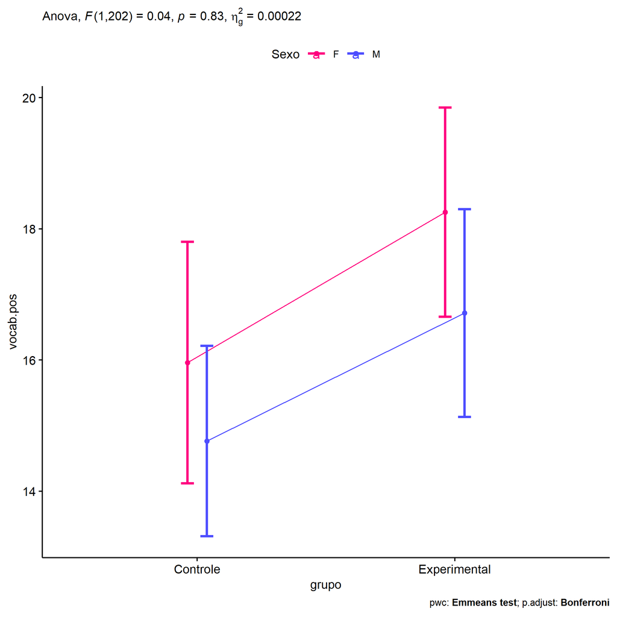

```r
if (!is.null(plots[["grupo"]]))
  plots[["grupo"]] + ggplot2::scale_color_manual(values = color[["Sexo"]])
```

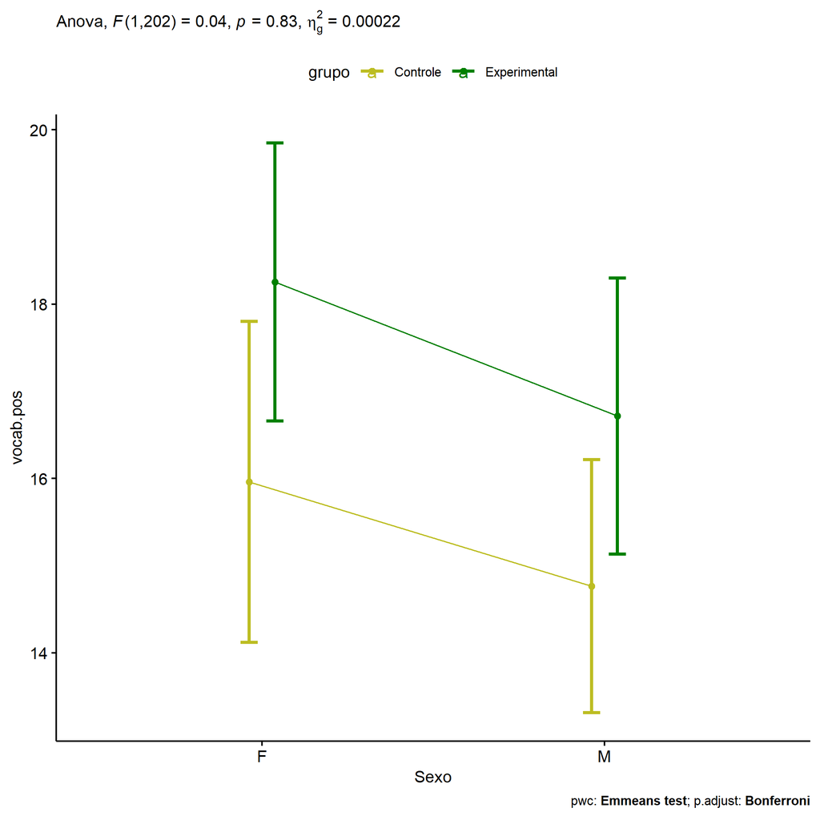

```r
if (!is.null(plots[["Sexo"]]))
  plots[["Sexo"]] + ggplot2::scale_color_manual(values = color[["grupo"]])
```

```r
plots <- twoWayAncovaBoxPlots(
  wdat, "vocab.pos", c("grupo","Sexo"), aov, pwcs, covar = "vocab.pre",
  theme = "classic", color = color[["grupo:Sexo"]],
  subtitle = which(aov$Effect == "grupo:Sexo"))
```

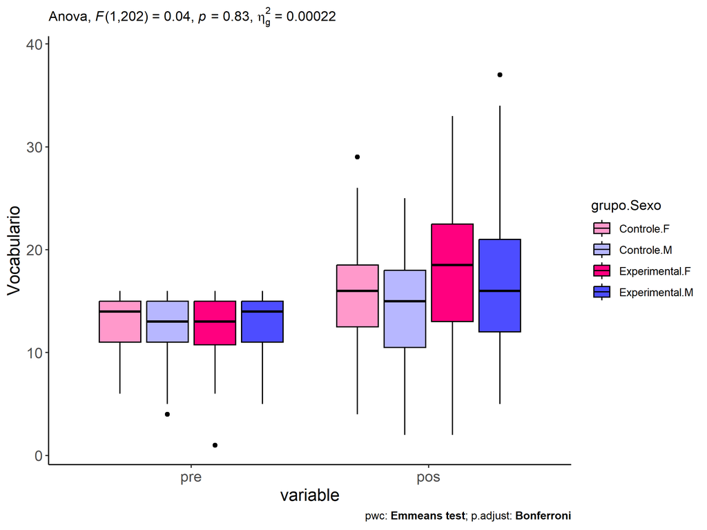

```r
plots[["grupo:Sexo"]] + ggplot2::ylab("Vocabulario") + ggplot2::scale_x_discrete(labels=c('pre', 'pos'))
```

```r
plots <- twoWayAncovaBoxPlots(
  wdat.long, "vocab", c("grupo","Sexo"), aov, pwc.long, pre.post = "time",
  theme = "classic", color = color$prepost)
```

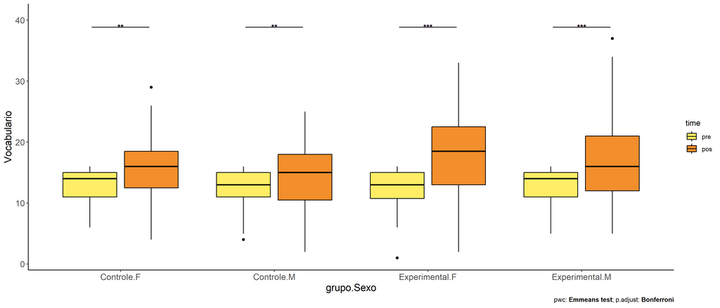

```r
plots[["grupo:Sexo"]] + ggplot2::ylab("Vocabulario")
```

### Checking linearity assumption

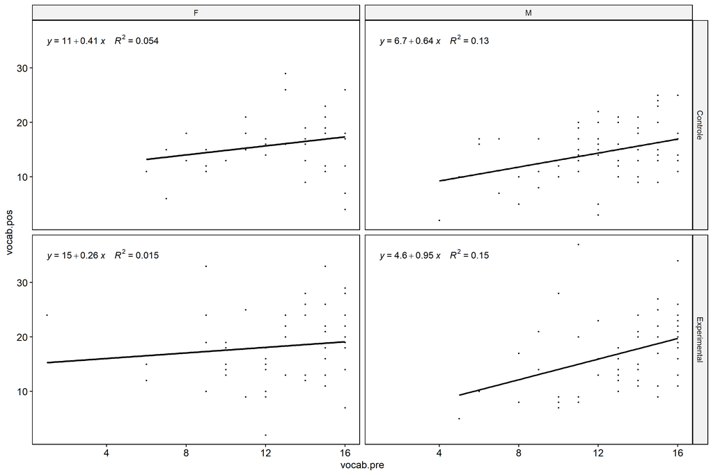

```r
ggscatter(wdat, x = "vocab.pre", y = "vocab.pos", size = 0.5,
          facet.by = c("grupo","Sexo"), add = "reg.line")+
  stat_regline_equation(
    aes(label =  paste(..eq.label.., ..rr.label.., sep = "~~~~"))
  )
```

### Checking normality and homogeneity

```r
res <- augment(lm(vocab.pos ~ vocab.pre + grupo*Sexo, data = wdat))
```

```r
shapiro_test(res$.resid)
```

```
## # A tibble: 1 × 3
##   variable   statistic p.value
##   <chr>          <dbl>   <dbl>
## 1 res$.resid     0.989   0.111
```

```r
levene_test(res, .resid ~ grupo*Sexo)
```

```
## # A tibble: 1 × 4
##     df1   df2 statistic     p
##   <int> <int>     <dbl> <dbl>
## 1     3   203      1.89 0.133
```

# ANCOVA and Pairwise for two factors **grupo:Zona**

## Without remove non-normal data

```r
pdat = remove_group_data(dat[!is.na(dat[["grupo"]]) & !is.na(dat[["Zona"]]),], "vocab.pos", c("grupo","Zona"))

pdat.long <- rbind(pdat[,c("id","grupo","Zona")], pdat[,c("id","grupo","Zona")])
pdat.long[["time"]] <- c(rep("pre", nrow(pdat)), rep("pos", nrow(pdat)))
pdat.long[["time"]] <- factor(pdat.long[["time"]], c("pre","pos"))
pdat.long[["vocab"]] <- c(pdat[["vocab.pre"]], pdat[["vocab.pos"]])

aov = anova_test(pdat, vocab.pos ~ vocab.pre + grupo*Zona)
laov[["grupo:Zona"]] <- get_anova_table(aov)
```

```r
pwcs <- list()
pwcs[["Zona"]] <- emmeans_test(
  group_by(pdat, grupo), vocab.pos ~ Zona,
  covariate = vocab.pre, p.adjust.method = "bonferroni")
pwcs[["grupo"]] <- emmeans_test(
  group_by(pdat, Zona), vocab.pos ~ grupo,
  covariate = vocab.pre, p.adjust.method = "bonferroni")

pwc <- plyr::rbind.fill(pwcs[["grupo"]], pwcs[["Zona"]])
pwc <- pwc[,c("grupo","Zona", colnames(pwc)[!colnames(pwc) %in% c("grupo","Zona")])]
```

```r
pwc.long <- emmeans_test(dplyr::group_by_at(pdat.long, c("grupo","Zona")),
                         vocab ~ time,
                         p.adjust.method = "bonferroni")
lpwc[["grupo:Zona"]] <- plyr::rbind.fill(pwc, pwc.long)
```

```r
ds <- get.descriptives(pdat, "vocab.pos", c("grupo","Zona"), covar = "vocab.pre")
ds <- merge(ds[ds$variable != "vocab.pre",],
            ds[ds$variable == "vocab.pre", !colnames(ds) %in% c("variable")],
            by = c("grupo","Zona"), all.x = T, suffixes = c("", ".vocab.pre"))
ds <- merge(get_emmeans(pwcs[["grupo"]]), ds, by = c("grupo","Zona"), suffixes = c(".emms", ""))
ds <- ds[,c("grupo","Zona","n","mean.vocab.pre","se.vocab.pre","mean","se","emmean","se.emms")]

colnames(ds) <- c("grupo","Zona", "N", paste0(c("M","SE")," (pre)"),
                  paste0(c("M","SE"), " (unadj)"), paste0(c("M", "SE"), " (adj)"))

lemms[["grupo:Zona"]] <- ds
```

## Computing ANCOVA and PairWise After removing non-normal data (OK)

```r
wdat = pdat

res = residuals(lm(vocab.pos ~ vocab.pre + grupo*Zona, data = wdat))
non.normal = getNonNormal(res, wdat$id, plimit = 0.05)

wdat = wdat[!wdat$id %in% non.normal,]

wdat.long <- rbind(wdat[,c("id","grupo","Zona")], wdat[,c("id","grupo","Zona")])
wdat.long[["time"]] <- c(rep("pre", nrow(wdat)), rep("pos", nrow(wdat)))
wdat.long[["time"]] <- factor(wdat.long[["time"]], c("pre","pos"))
wdat.long[["vocab"]] <- c(wdat[["vocab.pre"]], wdat[["vocab.pos"]])


ldat[["grupo:Zona"]] = wdat

(non.normal)
```

```
## [1] "P852"
```

```r
aov = anova_test(wdat, vocab.pos ~ vocab.pre + grupo*Zona)
laov[["grupo:Zona"]] <- merge(get_anova_table(aov), laov[["grupo:Zona"]], by="Effect", suffixes = c("","'"))

(df = get_anova_table(aov))
```

```
## ANOVA Table (type II tests)
##
##       Effect DFn DFd      F        p p<.05      ges
## 1  vocab.pre   1 142 13.538 0.000331     * 8.70e-02
## 2      grupo   1 142  7.293 0.008000     * 4.90e-02
## 3       Zona   1 142  0.002 0.965000       1.34e-05
## 4 grupo:Zona   1 142  0.097 0.756000       6.85e-04
```

| Effect | DFn | DFd | F | p | p<.05 | ges |
| --- | --- | --- | --- | --- | --- | --- |
| vocab.pre | 1 | 142 | 13.538 | 0.000 | * | 0.087 |
| grupo | 1 | 142 | 7.293 | 0.008 | * | 0.049 |
| Zona | 1 | 142 | 0.002 | 0.965 |  | 0.000 |
| grupo:Zona | 1 | 142 | 0.097 | 0.756 |  | 0.001 |

```r
pwcs <- list()
pwcs[["Zona"]] <- emmeans_test(
  group_by(wdat, grupo), vocab.pos ~ Zona,
  covariate = vocab.pre, p.adjust.method = "bonferroni")
pwcs[["grupo"]] <- emmeans_test(
  group_by(wdat, Zona), vocab.pos ~ grupo,
  covariate = vocab.pre, p.adjust.method = "bonferroni")

pwc <- plyr::rbind.fill(pwcs[["grupo"]], pwcs[["Zona"]])
pwc <- pwc[,c("grupo","Zona", colnames(pwc)[!colnames(pwc) %in% c("grupo","Zona")])]
```

| grupo | Zona | term | .y. | group1 | group2 | df | statistic | p | p.adj | p.adj.signif |
| --- | --- | --- | --- | --- | --- | --- | --- | --- | --- | --- |
|  | Rural | vocab.pre*grupo | vocab.pos | Controle | Experimental | 142 | -2.421 | 0.017 | 0.017 | * |
|  | Urbana | vocab.pre*grupo | vocab.pos | Controle | Experimental | 142 | -1.227 | 0.222 | 0.222 | ns |
| Controle |  | vocab.pre*Zona | vocab.pos | Rural | Urbana | 142 | -0.262 | 0.794 | 0.794 | ns |
| Experimental |  | vocab.pre*Zona | vocab.pos | Rural | Urbana | 142 | 0.176 | 0.860 | 0.860 | ns |

```r
pwc.long <- emmeans_test(dplyr::group_by_at(wdat.long, c("grupo","Zona")),
                         vocab ~ time,
                         p.adjust.method = "bonferroni")
lpwc[["grupo:Zona"]] <- merge(plyr::rbind.fill(pwc, pwc.long), lpwc[["grupo:Zona"]], by=c("grupo","Zona","term",".y.","group1","group2"), suffixes = c("","'"))
```

| grupo | Zona | term | .y. | group1 | group2 | df | statistic | p | p.adj | p.adj.signif |
| --- | --- | --- | --- | --- | --- | --- | --- | --- | --- | --- |
| Controle | Rural | time | vocab | pre | pos | 286 | -2.069 | 0.039 | 0.039 | * |
| Controle | Urbana | time | vocab | pre | pos | 286 | -1.611 | 0.108 | 0.108 | ns |
| Experimental | Rural | time | vocab | pre | pos | 286 | -5.111 | 0.000 | 0.000 | **** |
| Experimental | Urbana | time | vocab | pre | pos | 286 | -3.266 | 0.001 | 0.001 | ** |

```r
ds <- get.descriptives(wdat, "vocab.pos", c("grupo","Zona"), covar = "vocab.pre")
ds <- merge(ds[ds$variable != "vocab.pre",],
            ds[ds$variable == "vocab.pre", !colnames(ds) %in% c("variable")],
            by = c("grupo","Zona"), all.x = T, suffixes = c("", ".vocab.pre"))
ds <- merge(get_emmeans(pwcs[["grupo"]]), ds, by = c("grupo","Zona"), suffixes = c(".emms", ""))
ds <- ds[,c("grupo","Zona","n","mean.vocab.pre","se.vocab.pre","mean","se","emmean","se.emms")]

colnames(ds) <- c("grupo","Zona", "N", paste0(c("M","SE")," (pre)"),
                  paste0(c("M","SE"), " (unadj)"), paste0(c("M", "SE"), " (adj)"))

lemms[["grupo:Zona"]] <- merge(ds, lemms[["grupo:Zona"]], by=c("grupo","Zona"), suffixes = c("","'"))
```

| grupo | Zona | N | M (pre) | SE (pre) | M (unadj) | SE (unadj) | M (adj) | SE (adj) |
| --- | --- | --- | --- | --- | --- | --- | --- | --- |
| Controle | Rural | 51 | 12.706 | 0.415 | 14.686 | 0.791 | 14.683 | 0.828 |
| Controle | Urbana | 19 | 12.368 | 0.608 | 14.895 | 1.003 | 15.099 | 1.357 |
| Experimental | Rural | 50 | 12.420 | 0.414 | 17.360 | 1.045 | 17.533 | 0.837 |
| Experimental | Urbana | 27 | 13.444 | 0.609 | 17.741 | 1.079 | 17.283 | 1.144 |

### Plots for ancova

```r
plots <- twoWayAncovaPlots(
  wdat, "vocab.pos", c("grupo","Zona"), aov, pwcs, addParam = c("mean_se"),
  font.label.size=10, step.increase=0.05, p.label="p.adj",
  subtitle = which(aov$Effect == "grupo:Zona"))
```

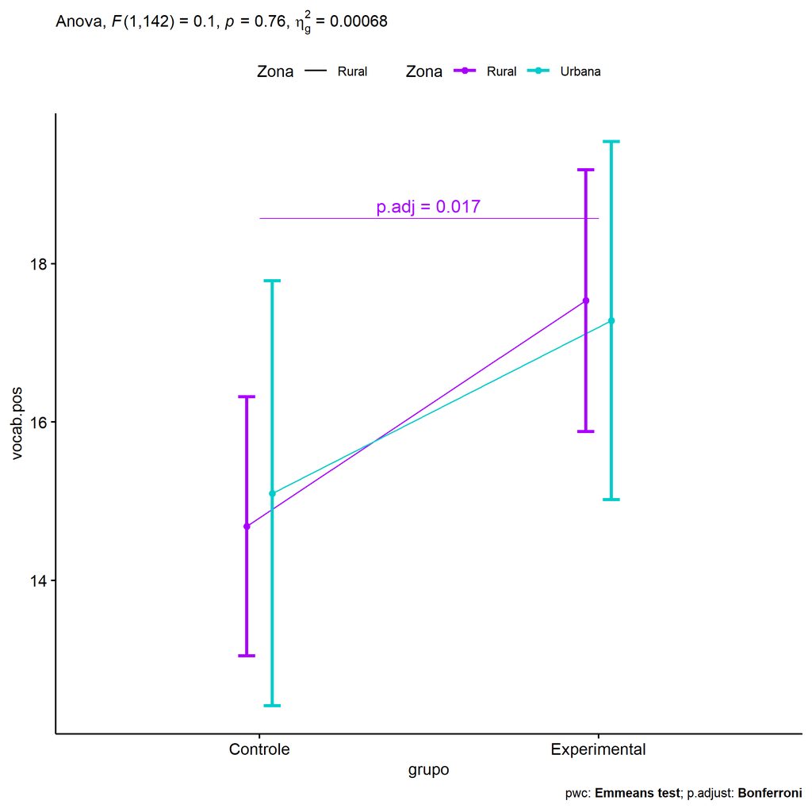

```r
if (!is.null(plots[["grupo"]]))
  plots[["grupo"]] + ggplot2::scale_color_manual(values = color[["Zona"]])
```

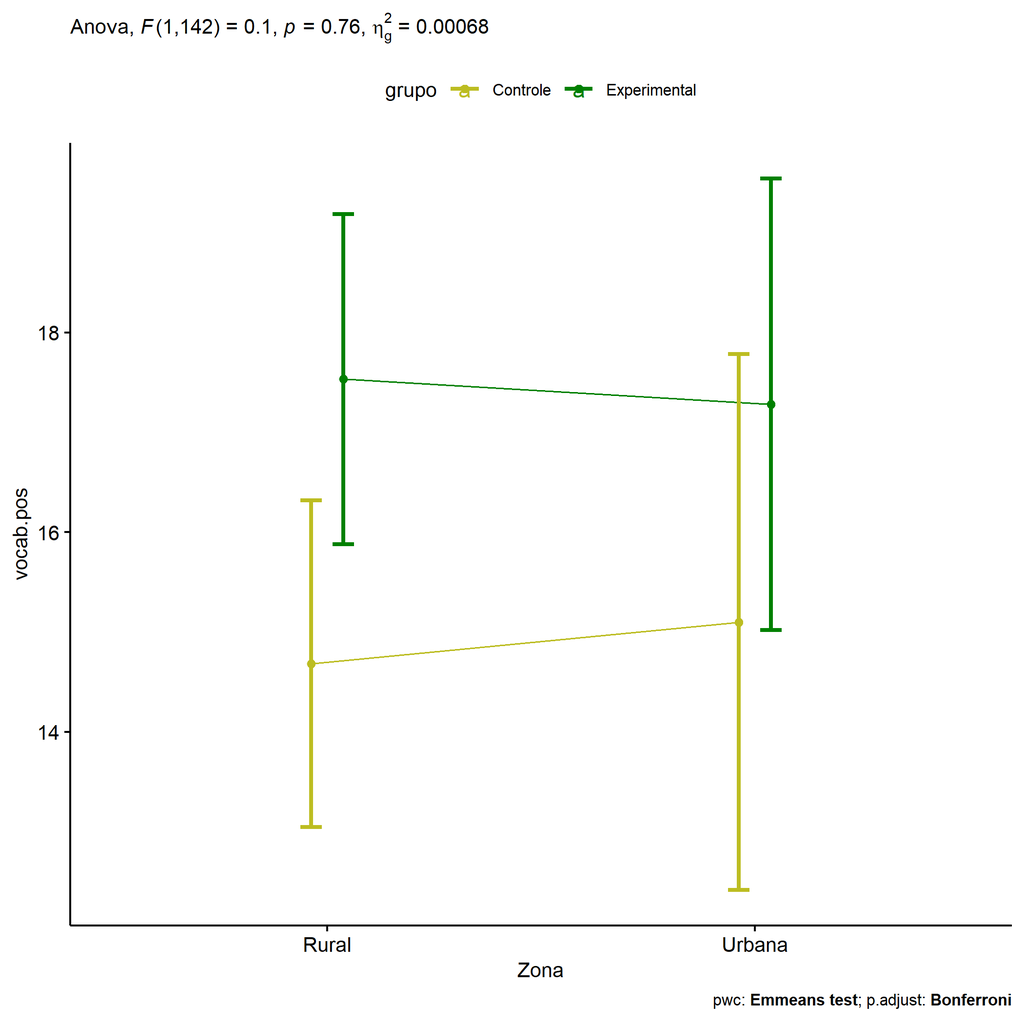

```r
if (!is.null(plots[["Zona"]]))
  plots[["Zona"]] + ggplot2::scale_color_manual(values = color[["grupo"]])
```

```r
plots <- twoWayAncovaBoxPlots(
  wdat, "vocab.pos", c("grupo","Zona"), aov, pwcs, covar = "vocab.pre",
  theme = "classic", color = color[["grupo:Zona"]],
  subtitle = which(aov$Effect == "grupo:Zona"))
```

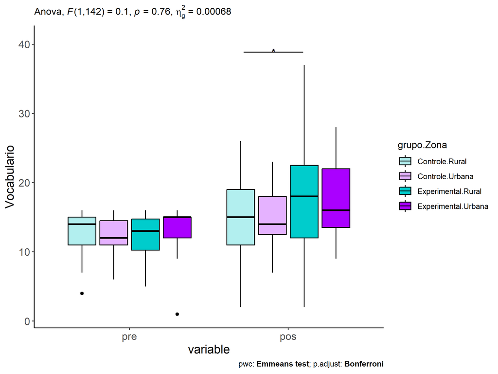

```r
plots[["grupo:Zona"]] + ggplot2::ylab("Vocabulario") + ggplot2::scale_x_discrete(labels=c('pre', 'pos'))
```

```r
plots <- twoWayAncovaBoxPlots(
  wdat.long, "vocab", c("grupo","Zona"), aov, pwc.long, pre.post = "time",
  theme = "classic", color = color$prepost)
```

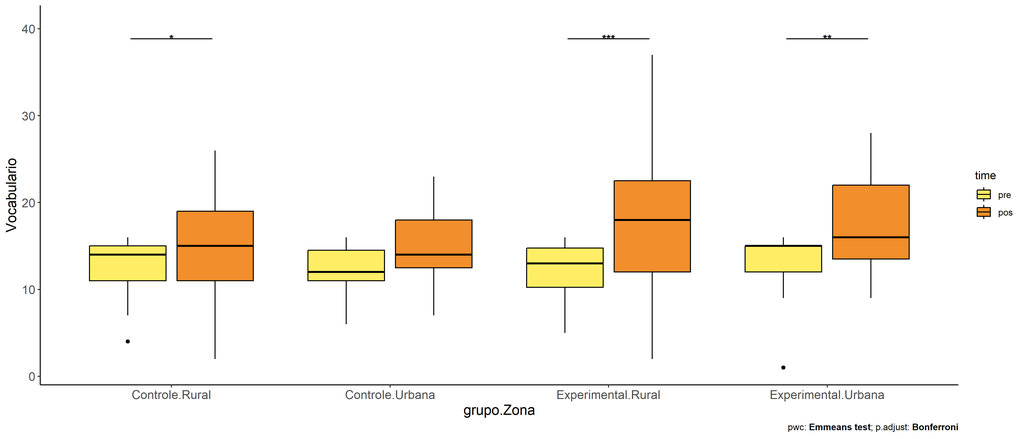

```r
plots[["grupo:Zona"]] + ggplot2::ylab("Vocabulario")
```

### Checking linearity assumption

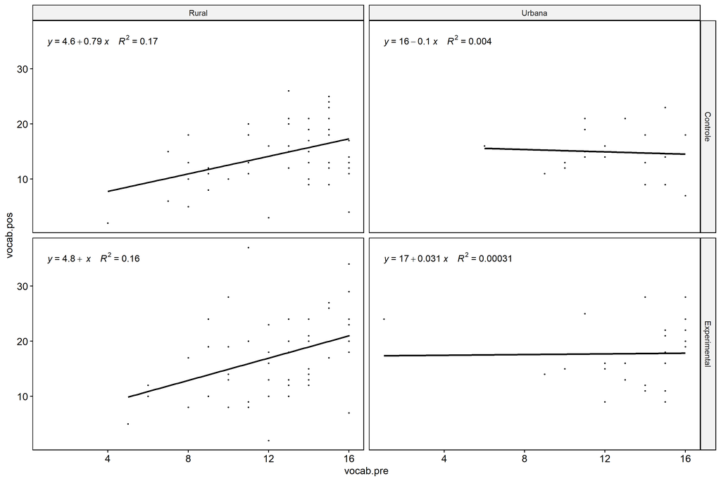

```r
ggscatter(wdat, x = "vocab.pre", y = "vocab.pos", size = 0.5,
          facet.by = c("grupo","Zona"), add = "reg.line")+
  stat_regline_equation(
    aes(label =  paste(..eq.label.., ..rr.label.., sep = "~~~~"))
  )
```

### Checking normality and homogeneity

```r
res <- augment(lm(vocab.pos ~ vocab.pre + grupo*Zona, data = wdat))
```

```r
shapiro_test(res$.resid)
```

```
## # A tibble: 1 × 3
##   variable   statistic p.value
##   <chr>          <dbl>   <dbl>
## 1 res$.resid     0.992   0.588
```

```r
levene_test(res, .resid ~ grupo*Zona)
```

```
## # A tibble: 1 × 4
##     df1   df2 statistic     p
##   <int> <int>     <dbl> <dbl>
## 1     3   143      1.61 0.189
```

# ANCOVA and Pairwise for two factors **grupo:Cor.Raca**

## Without remove non-normal data

```r
pdat = remove_group_data(dat[!is.na(dat[["grupo"]]) & !is.na(dat[["Cor.Raca"]]),], "vocab.pos", c("grupo","Cor.Raca"))
pdat.long <- rbind(pdat[,c("id","grupo","Cor.Raca")], pdat[,c("id","grupo","Cor.Raca")])
pdat.long[["time"]] <- c(rep("pre", nrow(pdat)), rep("pos", nrow(pdat)))
pdat.long[["time"]] <- factor(pdat.long[["time"]], c("pre","pos"))
pdat.long[["vocab"]] <- c(pdat[["vocab.pre"]], pdat[["vocab.pos"]])

aov = anova_test(pdat, vocab.pos ~ vocab.pre + grupo*Cor.Raca)
laov[["grupo:Cor.Raca"]] <- get_anova_table(aov)
```

```r
pwcs <- list()
pwcs[["Cor.Raca"]] <- emmeans_test(
  group_by(pdat, grupo), vocab.pos ~ Cor.Raca,
  covariate = vocab.pre, p.adjust.method = "bonferroni")
pwcs[["grupo"]] <- emmeans_test(
  group_by(pdat, Cor.Raca), vocab.pos ~ grupo,
  covariate = vocab.pre, p.adjust.method = "bonferroni")

pwc <- plyr::rbind.fill(pwcs[["grupo"]], pwcs[["Cor.Raca"]])
pwc <- pwc[,c("grupo","Cor.Raca", colnames(pwc)[!colnames(pwc) %in% c("grupo","Cor.Raca")])]
```

```r
pwc.long <- emmeans_test(dplyr::group_by_at(pdat.long, c("grupo","Cor.Raca")),
                         vocab ~ time,
                         p.adjust.method = "bonferroni")
lpwc[["grupo:Cor.Raca"]] <- plyr::rbind.fill(pwc, pwc.long)
```

```r
ds <- get.descriptives(pdat, "vocab.pos", c("grupo","Cor.Raca"), covar = "vocab.pre")
ds <- merge(ds[ds$variable != "vocab.pre",],
            ds[ds$variable == "vocab.pre", !colnames(ds) %in% c("variable")],
            by = c("grupo","Cor.Raca"), all.x = T, suffixes = c("", ".vocab.pre"))
ds <- merge(get_emmeans(pwcs[["grupo"]]), ds, by = c("grupo","Cor.Raca"), suffixes = c(".emms", ""))
ds <- ds[,c("grupo","Cor.Raca","n","mean.vocab.pre","se.vocab.pre","mean","se","emmean","se.emms")]

colnames(ds) <- c("grupo","Cor.Raca", "N", paste0(c("M","SE")," (pre)"),
                  paste0(c("M","SE"), " (unadj)"), paste0(c("M", "SE"), " (adj)"))

lemms[["grupo:Cor.Raca"]] <- ds
```

## Computing ANCOVA and PairWise After removing non-normal data (OK)

```r
wdat = pdat

res = residuals(lm(vocab.pos ~ vocab.pre + grupo*Cor.Raca, data = wdat))
non.normal = getNonNormal(res, wdat$id, plimit = 0.05)

wdat = wdat[!wdat$id %in% non.normal,]

wdat.long <- rbind(wdat[,c("id","grupo","Cor.Raca")], wdat[,c("id","grupo","Cor.Raca")])
wdat.long[["time"]] <- c(rep("pre", nrow(wdat)), rep("pos", nrow(wdat)))
wdat.long[["time"]] <- factor(wdat.long[["time"]], c("pre","pos"))
wdat.long[["vocab"]] <- c(wdat[["vocab.pre"]], wdat[["vocab.pos"]])


ldat[["grupo:Cor.Raca"]] = wdat

(non.normal)
```

```
## [1] "P852"
```

```r
aov = anova_test(wdat, vocab.pos ~ vocab.pre + grupo*Cor.Raca)
laov[["grupo:Cor.Raca"]] <- merge(get_anova_table(aov), laov[["grupo:Cor.Raca"]], by="Effect", suffixes = c("","'"))

(df = get_anova_table(aov))
```

```
## ANOVA Table (type II tests)
##
##           Effect DFn DFd      F     p p<.05   ges
## 1      vocab.pre   1  88  5.986 0.016     * 0.064
## 2          grupo   1  88 10.581 0.002     * 0.107
## 3       Cor.Raca   2  88  0.542 0.583       0.012
## 4 grupo:Cor.Raca   1  88  2.136 0.147       0.024
```

| Effect | DFn | DFd | F | p | p<.05 | ges |
| --- | --- | --- | --- | --- | --- | --- |
| vocab.pre | 1 | 88 | 5.986 | 0.016 | * | 0.064 |
| grupo | 1 | 88 | 10.581 | 0.002 | * | 0.107 |
| Cor.Raca | 2 | 88 | 0.542 | 0.583 |  | 0.012 |
| grupo:Cor.Raca | 1 | 88 | 2.136 | 0.147 |  | 0.024 |

```r
pwcs <- list()
pwcs[["Cor.Raca"]] <- emmeans_test(
  group_by(wdat, grupo), vocab.pos ~ Cor.Raca,
  covariate = vocab.pre, p.adjust.method = "bonferroni")
pwcs[["grupo"]] <- emmeans_test(
  group_by(wdat, Cor.Raca), vocab.pos ~ grupo,
  covariate = vocab.pre, p.adjust.method = "bonferroni")

pwc <- plyr::rbind.fill(pwcs[["grupo"]], pwcs[["Cor.Raca"]])
pwc <- pwc[,c("grupo","Cor.Raca", colnames(pwc)[!colnames(pwc) %in% c("grupo","Cor.Raca")])]
```

| grupo | Cor.Raca | term | .y. | group1 | group2 | df | statistic | p | p.adj | p.adj.signif |
| --- | --- | --- | --- | --- | --- | --- | --- | --- | --- | --- |
|  | Branca | vocab.pre*grupo | vocab.pos | Controle | Experimental | 88 | 0.235 | 0.815 | 0.815 | ns |
|  | Indígena | vocab.pre*grupo | vocab.pos | Controle | Experimental |  |  |  |  |  |
|  | Parda | vocab.pre*grupo | vocab.pos | Controle | Experimental | 88 | -3.561 | 0.001 | 0.001 | *** |
| Controle |  | vocab.pre*Cor.Raca | vocab.pos | Branca | Indígena |  |  |  |  |  |
| Controle |  | vocab.pre*Cor.Raca | vocab.pos | Branca | Parda | 88 | 0.562 | 0.576 | 0.576 | ns |
| Controle |  | vocab.pre*Cor.Raca | vocab.pos | Indígena | Parda |  |  |  |  |  |
| Experimental |  | vocab.pre*Cor.Raca | vocab.pos | Branca | Indígena | 88 | -0.464 | 0.644 | 1.000 | ns |
| Experimental |  | vocab.pre*Cor.Raca | vocab.pos | Branca | Parda | 88 | -1.490 | 0.140 | 0.419 | ns |
| Experimental |  | vocab.pre*Cor.Raca | vocab.pos | Indígena | Parda | 88 | -1.067 | 0.289 | 0.866 | ns |

```r
pwc.long <- emmeans_test(dplyr::group_by_at(wdat.long, c("grupo","Cor.Raca")),
                         vocab ~ time,
                         p.adjust.method = "bonferroni")
lpwc[["grupo:Cor.Raca"]] <- merge(plyr::rbind.fill(pwc, pwc.long), lpwc[["grupo:Cor.Raca"]], by=c("grupo","Cor.Raca","term",".y.","group1","group2"), suffixes = c("","'"))
```

| grupo | Cor.Raca | term | .y. | group1 | group2 | df | statistic | p | p.adj | p.adj.signif |
| --- | --- | --- | --- | --- | --- | --- | --- | --- | --- | --- |
| Controle | Branca | time | vocab | pre | pos | 178 | -1.276 | 0.204 | 0.204 | ns |
| Controle | Indígena | time | vocab | pre | pos |  |  |  |  |  |
| Controle | Parda | time | vocab | pre | pos | 178 | -1.165 | 0.245 | 0.245 | ns |
| Experimental | Branca | time | vocab | pre | pos | 178 | -0.399 | 0.690 | 0.690 | ns |
| Experimental | Indígena | time | vocab | pre | pos | 178 | -1.125 | 0.262 | 0.262 | ns |
| Experimental | Parda | time | vocab | pre | pos | 178 | -5.952 | 0.000 | 0.000 | **** |

```r
ds <- get.descriptives(wdat, "vocab.pos", c("grupo","Cor.Raca"), covar = "vocab.pre")
ds <- merge(ds[ds$variable != "vocab.pre",],
            ds[ds$variable == "vocab.pre", !colnames(ds) %in% c("variable")],
            by = c("grupo","Cor.Raca"), all.x = T, suffixes = c("", ".vocab.pre"))
ds <- merge(get_emmeans(pwcs[["grupo"]]), ds, by = c("grupo","Cor.Raca"), suffixes = c(".emms", ""))
ds <- ds[,c("grupo","Cor.Raca","n","mean.vocab.pre","se.vocab.pre","mean","se","emmean","se.emms")]

colnames(ds) <- c("grupo","Cor.Raca", "N", paste0(c("M","SE")," (pre)"),
                  paste0(c("M","SE"), " (unadj)"), paste0(c("M", "SE"), " (adj)"))

lemms[["grupo:Cor.Raca"]] <- merge(ds, lemms[["grupo:Cor.Raca"]], by=c("grupo","Cor.Raca"), suffixes = c("","'"))
```

| grupo | Cor.Raca | N | M (pre) | SE (pre) | M (unadj) | SE (unadj) | M (adj) | SE (adj) |
| --- | --- | --- | --- | --- | --- | --- | --- | --- |
| Controle | Branca | 6 | 11.333 | 1.054 | 14.833 | 1.922 | 15.602 | 2.430 |
| Controle | Parda | 36 | 12.861 | 0.429 | 14.167 | 0.849 | 14.128 | 0.984 |
| Experimental | Branca | 5 | 14.400 | 0.812 | 15.600 | 2.731 | 14.747 | 2.663 |
| Experimental | Indígena | 7 | 14.286 | 0.565 | 17.143 | 1.184 | 16.351 | 2.254 |
| Experimental | Parda | 40 | 12.475 | 0.539 | 18.800 | 1.145 | 18.965 | 0.936 |